# PS2

Author

Daniel Rubio

# PS2

Daniel Rubio, 9/26/24

As an aid to my problem solving, I used UM GPT to probe for explanations when I was confused, and for suggestions of possible built in functions to use. I did not copy and paste the prompts into the AI, but rather used it to answer the questions I had as they arose.

# Problem 1: Dice Game

## (a)/(b)

### i. Using a loop

```r
#' Function that plays Dice game using a for loop
#'
#' @param x the number of plays
#'
#' @return The net number of won or lost dollars after 'x' plays
#'
play_dice_1 <- function(x) {
  winnings <- 0

  for (i in 1:x) {
    #print(winnings)
    roll <- floor(runif(1,1,7))
    if ((roll == 3)||(roll == 5)){
      winnings <- winnings + 2*roll
    }
    else {
      winnings <- winnings - 2
    }
  }

  return(winnings)

}

play_dice_1(3)
```

```
[1] 14
```

```r
play_dice_1(30)
```

```
[1] 28
```

```r
play_dice_1(300)
```

```
[1] 500
```

```r
play_dice_1(3000)
```

```
[1] 3840
```

### ii. Using an R vectorized function

```r
#' Function that plays Dice game using vectorized functions
#'
#' @param x the number of plays
#'
#' @return The net number of won or lost dollars after 'x' plays
#'
play_dice_2 <- function(x) {
  rolls <- floor(runif(x,1,7))
  rolls[rolls == 6] <- -2 # This is a dangerous way to do it, originally this line was last and it was overriding all the 3 rolls that had previously become 6. However since this is for a timing problem I moved this to first and it works now
  rolls[rolls == 1] <- -2
  rolls[rolls == 2] <- -2
  rolls[rolls == 3] <- 6
  rolls[rolls == 4] <- -2
  rolls[rolls == 5] <- 10

  winnings = sum(rolls)

  return(winnings)
}
play_dice_2(3)
```

```
[1] 14
```

```r
play_dice_2(30)
```

```
[1] 76
```

```r
play_dice_2(300)
```

```
[1] 548
```

```r
play_dice_2(3000)
```

```
[1] 4256
```

### iii. Using table()

```r
#' Function that plays Dice game using table()
#'
#' @param x the number of plays
#'
#' @return The net number of won or lost dollars after 'x' plays
#'
play_dice_3 <- function(x) {
  rolls <- floor(runif(x,1,7))
  results <- table(rolls)
  outcomes <- c("1"=-2,"2"=-2,"3"=6,"4"=-2,"5"=10,"6"=-2)
  winnings <- 0

  for (i in 1:length(results)){
    num_name <- names(results)[i]
    winnings <- winnings + results[num_name]*outcomes[num_name]
  }

  return(winnings[[1]])
}
play_dice_3(3)
```

```
[1] 2
```

```r
play_dice_3(30)
```

```
[1] 40
```

```r
play_dice_3(300)
```

```
[1] 300
```

```r
play_dice_3(3000)
```

```
[1] 4128
```

### iv. Using apply()

```r
#' Function that plays Dice game using apply()
#'
#' @param x the number of plays
#'
#' @return The net number of won or lost dollars after 'x' plays
#'
play_dice_4 <- function(x) {
  rolls <- floor(runif(x,1,7))

  results <- sapply(rolls, function(x){
    if(x==3){return(6)}
    else if(x==5){return(10)}
    else{return(-2)}
  })
  winnings <- sum(results)
  return(winnings)
}
play_dice_4(3)
```

```
[1] 14
```

```r
play_dice_4(30)
```

```
[1] 32
```

```r
play_dice_4(300)
```

```
[1] 368
```

```r
play_dice_4(3000)
```

```
[1] 4456
```

## (c)

```r
three_ans <- vector(length=4)
three_thou_ans <- vector(length=4)
set.seed(2024)
three_ans[1] <- play_dice_1(3)
set.seed(2024)
three_ans[2] <- play_dice_2(3)
set.seed(2024)
three_ans[3] <- play_dice_3(3)
set.seed(2024)
three_ans[4] <- play_dice_4(3)

set.seed(2024)
three_thou_ans[1] <- play_dice_1(3000)
set.seed(2024)
three_thou_ans[2] <- play_dice_2(3000)
set.seed(2024)
three_thou_ans[3] <- play_dice_3(3000)
set.seed(2024)
three_thou_ans[4] <- play_dice_4(3000)

print(three_ans)
```

```
[1] 6 6 6 6
```

```r
print(three_thou_ans)
```

```
[1] 4304 4304 4304 4304
```

## (d)

```r
#install.packages("microbenchmark") # ran once
library(microbenchmark)
few_rounds <- 1000
low_in <- microbenchmark(
  play_dice_1 = play_dice_1(few_rounds),
  play_dice_2 = play_dice_2(few_rounds),
  play_dice_3 = play_dice_3(few_rounds),
  play_dice_4 = play_dice_4(few_rounds)
)
print(low_in) # units are microseconds
```

```
Unit: microseconds
        expr     min       lq      mean   median       uq      max neval
 play_dice_1 567.959 576.8965 615.30360 588.1675 598.3760 1816.459   100
 play_dice_2  73.168  75.4590  80.82782  80.3545  84.3760  100.459   100
 play_dice_3 569.126 575.9385 593.89111 590.1050 602.0215  697.292   100
 play_dice_4 382.168 393.4590 403.82942 398.2710 411.7510  459.334   100
```

```r
many_rounds <- 100000
high_in <- microbenchmark(
  play_dice_1 = play_dice_1(many_rounds),
  play_dice_2 = play_dice_2(many_rounds),
  play_dice_3 = play_dice_3(many_rounds),
  play_dice_4 = play_dice_4(many_rounds)
)
print(high_in) # units are miliseconds
```

```
Unit: milliseconds
        expr       min        lq      mean    median        uq        max neval
 play_dice_1 56.481418 60.067313 64.266835 61.936917 64.314021 129.205417   100
 play_dice_2  6.830917  6.999125  7.278243  7.117625  7.464375   9.388125   100
 play_dice_3 49.885167 50.795188 52.221592 51.356063 51.897168  87.467043   100
 play_dice_4 41.025251 45.110168 52.026044 47.854001 53.401855 131.767292   100
```

The built in R-vectorization is the fastest for the smaller and the larger cases of the gameplay. This makes sense as from what I understand since R vectorization calls down to C. For small cases, it seems as though table() and loops take similar amount of time, in fact some of the time loops are slightly faster than table(). For larger cases the table() method becomes noticeably faster than loops. Apply is consistently the second fastest but vectorized is the clear winner.

## (e)

```r
set.seed(2024) # for reproducability

num_simulations <- 10000

results <- numeric(num_simulations)
num_plays <- floor(runif(num_simulations,1,100000))

for (i in 1:num_simulations) {
  results[i] <- play_dice_2(num_plays[i])
}

summary(results)
```

```
   Min. 1st Qu.  Median    Mean 3rd Qu.    Max.
     -8   33703   66704   66634   99919  136352
```

```r
t_test_results <- t.test(results, mu = 0)
print(t_test_results)
```

```
    One Sample t-test

data:  results
t = 173.83, df = 9999, p-value < 2.2e-16
alternative hypothesis: true mean is not equal to 0
95 percent confidence interval:
 65882.35 67385.12
sample estimates:
mean of x
 66633.73
```

The above code runs 10,000 games each with anywhere between 1 and 100,000 rolls each. If this game were fair then the mean score would be 0, which based on the 10,000 results and a t-test on the data seem to decisively not be true. Therefore based on my Monte Carlo simulation I don’t think it’s a fair game from the house perspective, but I would love to play it as it seems very in favor of the roller.

```r
rm(list=ls())
```

# Problem 2: Linear Regression

## (a)

```r
df <- read.csv("cars.csv")
names <- c("height",'length','width','drive','engine','is_hybrid','n_gears','transmission',
           'c_mpg','fuel','h_mpg','classification','id','make','model_year','year','hp','tor')
colnames(df) <- names
```

## (b)

```r
nrow(df)
```

```
[1] 5076
```

```r
df <- df[df$fuel== "Gasoline",]
nrow(df)
```

```
[1] 4591
```

## (c)

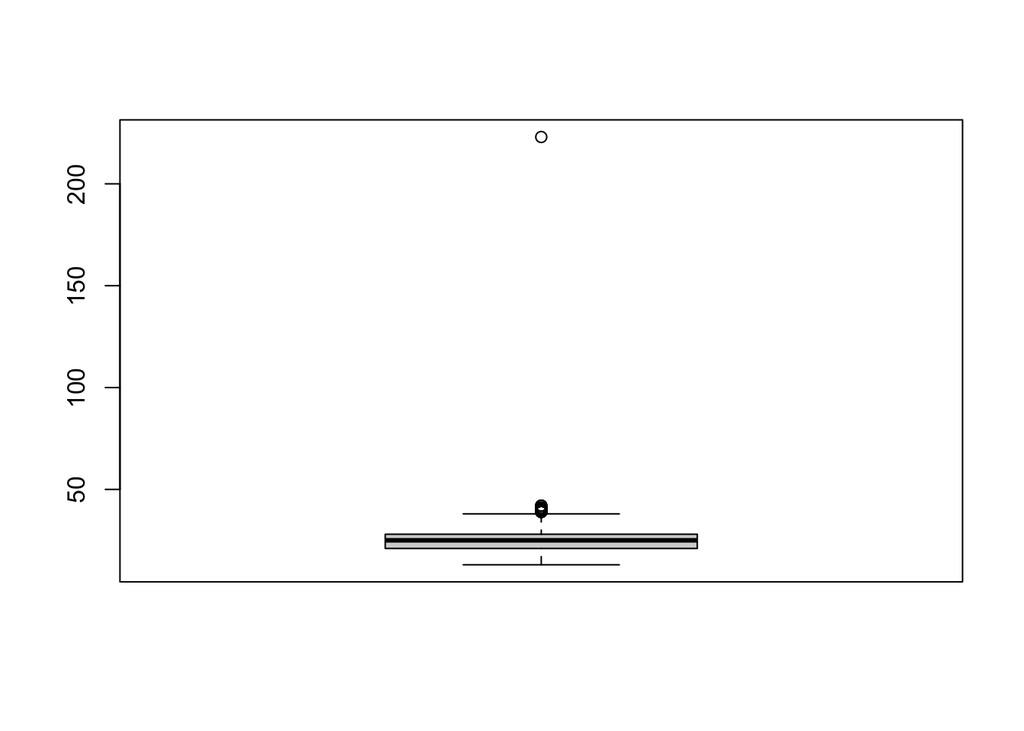

```r
boxplot(df$h_mpg)
```

There is an outlier here, 2011 Chevy Silverado Hybrid appears to have a 223 highway mpg. This is clearly untrue. According to the internet the true value is 23 mpg. I will update this

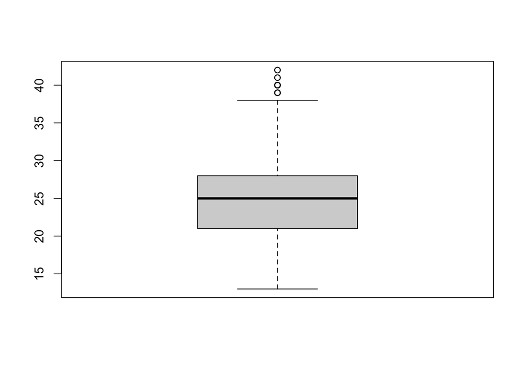

```r
df$h_mpg[which(df$h_mpg == 223)] <- 23
boxplot(df$h_mpg)
```

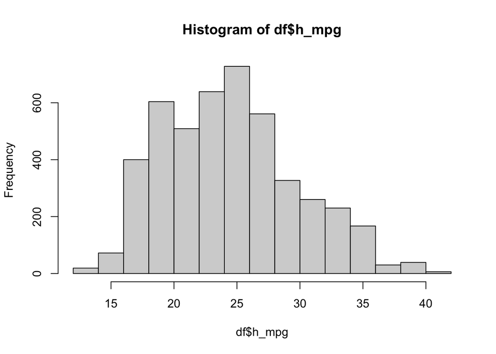

```r
hist(df$h_mpg)
```

After the removal of the outlier, the data seems normal enough that it would not require any further transformation.

## (d)

```r
df$cat_year <- as.factor(df$year)
model <- lm(h_mpg ~ tor + hp + height + length + width + cat_year, data=df)
summary(model)
```

```
Call:
lm(formula = h_mpg ~ tor + hp + height + length + width + cat_year,
    data = df)

Residuals:
     Min       1Q   Median       3Q      Max
-10.9674  -2.4992  -0.3696   2.4215  19.8059

Coefficients:
               Estimate Std. Error t value Pr(>|t|)
(Intercept)  32.4090351  0.5486073  59.075   <2e-16 ***
tor          -0.0517335  0.0016725 -30.931   <2e-16 ***
hp            0.0171143  0.0017289   9.899   <2e-16 ***
height        0.0104534  0.0008554  12.220   <2e-16 ***
length        0.0011517  0.0006709   1.717   0.0861 .
width        -0.0008078  0.0006867  -1.176   0.2395
cat_year2010 -0.4498283  0.5138553  -0.875   0.3814
cat_year2011  0.0724343  0.5130048   0.141   0.8877
cat_year2012  1.2927241  0.5170311   2.500   0.0124 *
---
Signif. codes:  0 '***' 0.001 '**' 0.01 '*' 0.05 '.' 0.1 ' ' 1

Residual standard error: 3.494 on 4582 degrees of freedom
Multiple R-squared:  0.5625,    Adjusted R-squared:  0.5618
F-statistic: 736.5 on 8 and 4582 DF,  p-value: < 2.2e-16
```

The estimate coefficient for torque is about -0.052. This means that for all other variables held constant, for the increase of one unit (likely pound-feet, although the original table does not specify) of torque, the highway mpg will go down by about 0.052 miles per gallon.

## (e)

```r
#table(df$cat_year)
model2 <- lm(h_mpg ~ tor*hp + height + length + width + cat_year, data=df)
summary(model2)
```

```
Call:
lm(formula = h_mpg ~ tor * hp + height + length + width + cat_year,
    data = df)

Residuals:
     Min       1Q   Median       3Q      Max
-11.2576  -2.2103  -0.2108   2.0916  21.6483

Coefficients:
               Estimate Std. Error t value Pr(>|t|)
(Intercept)   4.247e+01  5.706e-01  74.425  < 2e-16 ***
tor          -8.763e-02  1.823e-03 -48.075  < 2e-16 ***
hp           -1.644e-02  1.827e-03  -9.002  < 2e-16 ***
height        7.051e-03  7.696e-04   9.162  < 2e-16 ***
length        1.200e-03  5.985e-04   2.005  0.04498 *
width        -1.657e-03  6.131e-04  -2.702  0.00692 **
cat_year2010 -5.604e-01  4.584e-01  -1.222  0.22161
cat_year2011 -2.774e-02  4.577e-01  -0.061  0.95168
cat_year2012  1.185e+00  4.613e-01   2.569  0.01023 *
tor:hp        1.142e-04  3.330e-06  34.289  < 2e-16 ***
---
Signif. codes:  0 '***' 0.001 '**' 0.01 '*' 0.05 '.' 0.1 ' ' 1

Residual standard error: 3.117 on 4581 degrees of freedom
Multiple R-squared:  0.6519,    Adjusted R-squared:  0.6512
F-statistic: 953.1 on 9 and 4581 DF,  p-value: < 2.2e-16
```

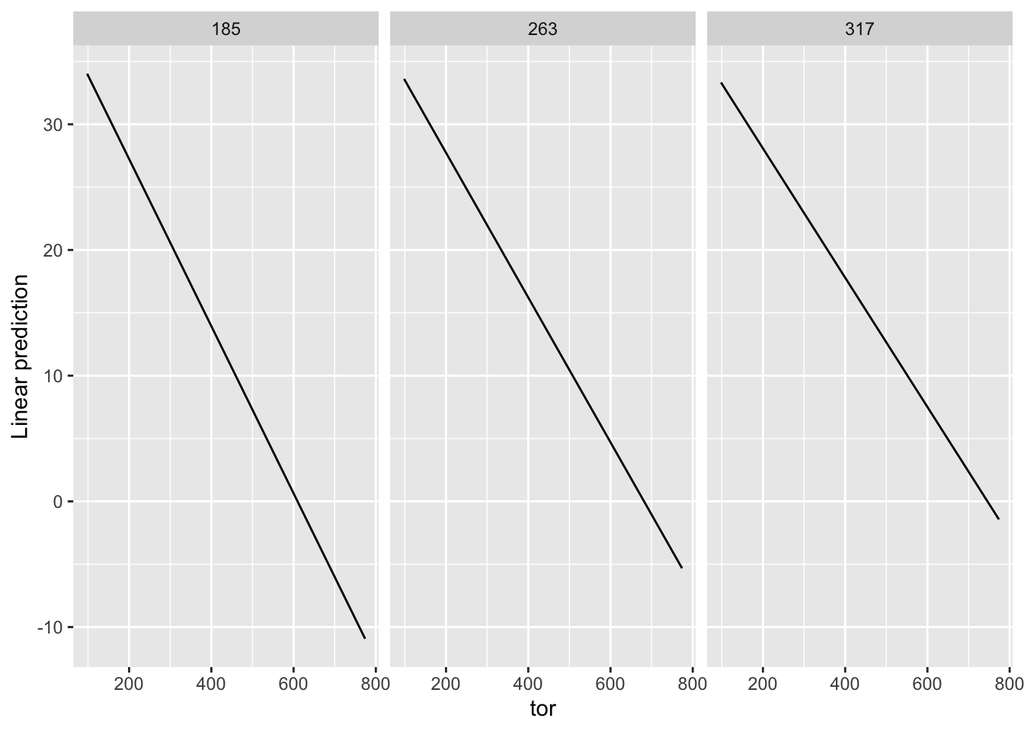

```r
#install.packages("emmeans")
#install.packages("ggplot2")
library(emmeans)
reasonable_torques <- seq(min(df$tor),max(df$tor),length.out = 100)
reasonable_hps <- quantile(df$hp,probs=c(0.25,0.5,0.75))
emmip(model2, ~ tor|hp, at=list(hp=reasonable_hps, tor=reasonable_torques),)
```

Across the middle 50% of horsepowers, the slope between torque and highway mpg becomes less steep as horsepower increases.

## (f)

```r
X <- model.matrix(h_mpg ~ tor + hp + height + length + width + cat_year, data=df)
Y <- df$h_mpg

XtXinv <- solve(t(X) %*% X)
b_hat <- XtXinv %*% t(X) %*% Y

print(b_hat)
```

```
                      [,1]
(Intercept)  32.4090350913
tor          -0.0517335160
hp            0.0171143024
height        0.0104533673
length        0.0011517430
width        -0.0008077671
cat_year2010 -0.4498282970
cat_year2011  0.0724342984
cat_year2012  1.2927241232
```

```r
print(as.matrix(model$coefficients))
```

```
                      [,1]
(Intercept)  32.4090350913
tor          -0.0517335160
hp            0.0171143024
height        0.0104533673
length        0.0011517430
width        -0.0008077671
cat_year2010 -0.4498282970
cat_year2011  0.0724342984
cat_year2012  1.2927241232
```

```r
print(all.equal(b_hat,as.matrix(model$coefficients)))
```

```
[1] TRUE
```

The coefficients found from lm() and the linear algebra approach are indeed the same.